# Stat 480 Group Project - Group 5

Dilin Chen, Saumil Padhya, Donghan Liu, Lijun Zhang

5/1/2018

# Introduction

People traveling by air for either work or leisure has been more and more popular, and has made the punctuality of planes being more critical. By punctuality, it means planes not being cancelled or delayed. Since various reasons may cause cancellation and delay of planes, with data provided by the US Department of Transportation“s Bureau of Transportation Statistics (BTS) for year of 2002 and 2005, the group has studied in different cancellation and delay trends, including different time ranges, airport location information, carriers, and plane model involved information. Analysis has formed for 2002 and 2005 data separately, and results have been compared to tell the difference of flight information in each year. Exploratory analysis and conclusion has been addressed in the following sections.

# Methods

## Data Processing

Our final data set contains data about the airlines, airports, carriers and planes. Multiple steps were involved in combining the data sets ’C

1. Transforming Data Sets: Some variables in the data sets (excluding the airlines data) have a comma (“,”) character, which prevents the variables from being read into hive in the correct order. “csvtransform.R” replaces “,” with “/,” so that data can be correctly read into hive using the escaped character “/”.
2. Combining Data Sets: The airports, carriers and planes data sets are combined with the airlines data set using hive. The resulting output of 52 variables is written to “AllAirlineData0205.csv” on the command line.
3. Big Matrix: “AllAirlineData0205.csv” is converted into 2 big matrix objects that contain integer variables and double variables. Some data processing is done before creating these matrix objects. The day, month and year are extracted from the variable “planeissuedate” and created as new variables (“planeissuedate” variable is discarded). Categorical variables are converted to integers 1:n where n is the number of levels. The unique factor names are stored in the R data set “nonintegerColFactors.Rda” for later use in visualizations. Finally, the processed data is written into 2 csv files ’C “AllAirlineData0205.csv” (integer variables) and “AirlineData0205Float.csv” (double type variables). Note that variables “originairport” (name of origin airport), “destairport” (name of destination airport), and “carrierdescription” are not part of the final data set.

Finally, 2 big matrix objects of type “integer” (air0205.bin) and “double” (air0205float.bin) are created.

## Assumptions

Since the number of flights, for instance during each month are different, then the exact number of cancelled flights or arrival delayed flights does not help making reasonable conclusions. The group has decided to create the following new variables. Cancellation Rate is computed by the number of cancelled flights over the number of flights for a same time range. This variable gives the probability of a flight to be cancelled, or the percentage of all flights to be cancelled during that certain time period. Arrival Delay Rate is calculated as number of flights has been delayed over number of flights for the same time period. This generated variable tells the probability of a flight facing arrival delay, or the percentage of all flights delayed at arrival. If these generated rate variables are of higher value, indicating a higher possibility of cancellation or arrival delay for that time range. On the other hand, a lower value means a smaller probability of cancellation or arrival delay.

For a lot of the visualizations involving treemaps and heatmaps, the 99th or 99.99th percentile of delays was used to take into account the worst delays. This measure was also used in part because more than 75% of the flights have no delays (0 delay) and thus, all statistics limited to 75th percentile contained little information.

# Results

## Cancellation v.s. Diversion

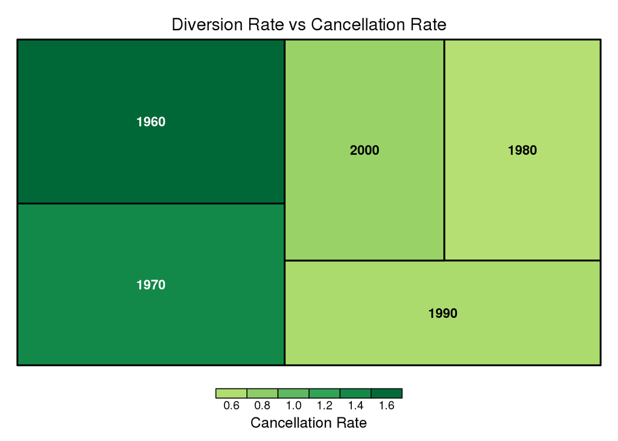

From treemap above, we can see that older planes have relatively higher diversion and cancellation rates. Planes manufactured before 1960s and in 1970s have a slightly higher diversion rate (averaging ~0.24%) and a significantly higher cancellation rate (averaging ~1.50%) than the planes manufactured after 1970s with diversion rate averaging ~0.19% and cancellation rate averaging ~0.65%.

## Flight number & Cancellation over the various time type

### Flight number by Months

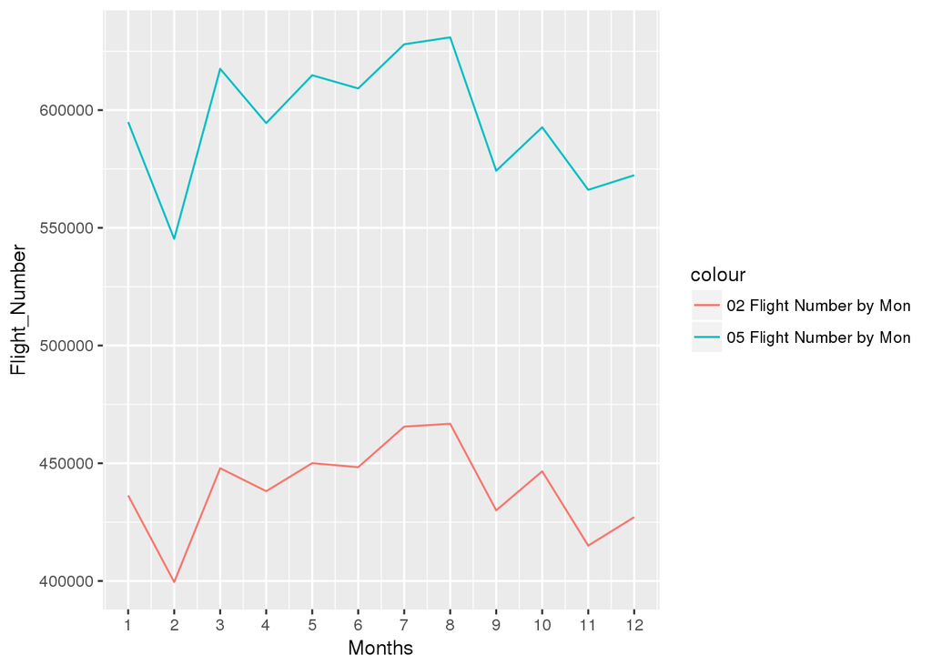

### Cancellation by Months

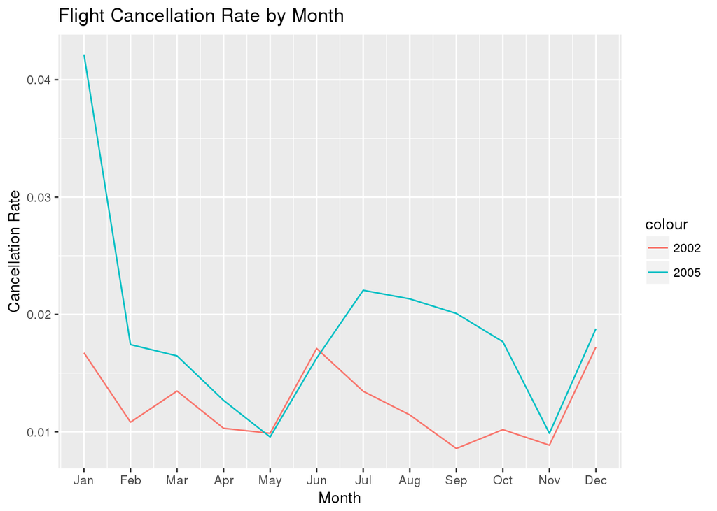

Since weather conditions vary from month to month every year, but a seasonal trend still lies in. Other conditions like the end or the beginning of fiscal year or natural year may affect business travels, the group has found interesting trends with each month as the time bins as following.

The cancellation rate for each month is generally higher in 2005 than in 2002, except in June 2002. For 2002, cancellation rate is higher in summer and winter, while lower in spring and fall with no huge fluctuations. For 2005, the cancellation rate is extremely high in January (more than 0.04) since there were heavy snow and mixed precipitation storm, and the cancellation rate is also high during the summer since Tropical Storm Arlene, and Hurricane Katrina at that time. Whereas, the comparisons from flight number between 2002 and 2005 shows that the flight number from 2005 has a huge increasing than the year of 2002, even though their general trends are approximately same. From the perspective of flight number trend, July and August have the relatively highest flight number among the corresponding year. This might be caused by the summer travel, especially for the academic and personal travel plan. The summer is the time that schools are in the breaks and students and teachers are going back to home, some companies like Amgen also choose to have their employee a nice summer break during the fourth of July. There is a huge decreasing between August and September, which might be influenced by Fall semester starts and people’s personal works are back to the normal track. The February is the lowest scheduled flight number for both 2002 and 2005.

### Arrival delay by month

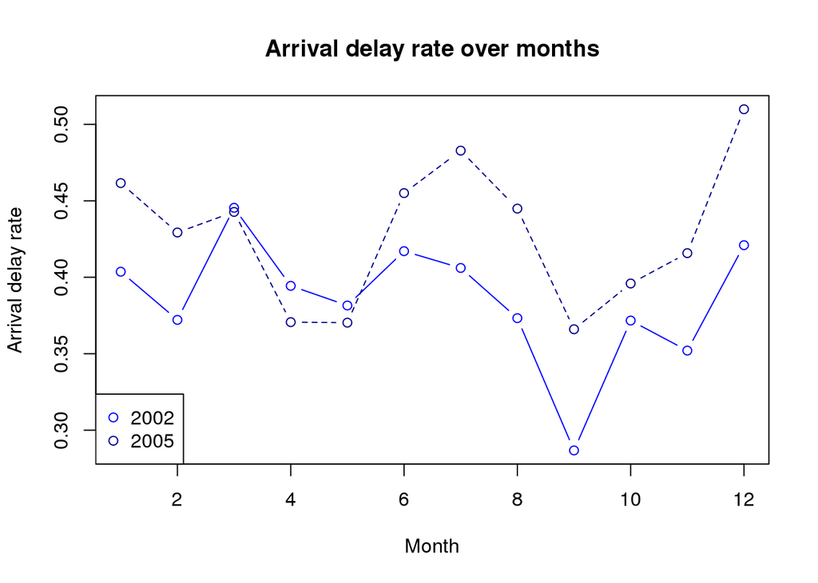

### Flight Number By Day of Week

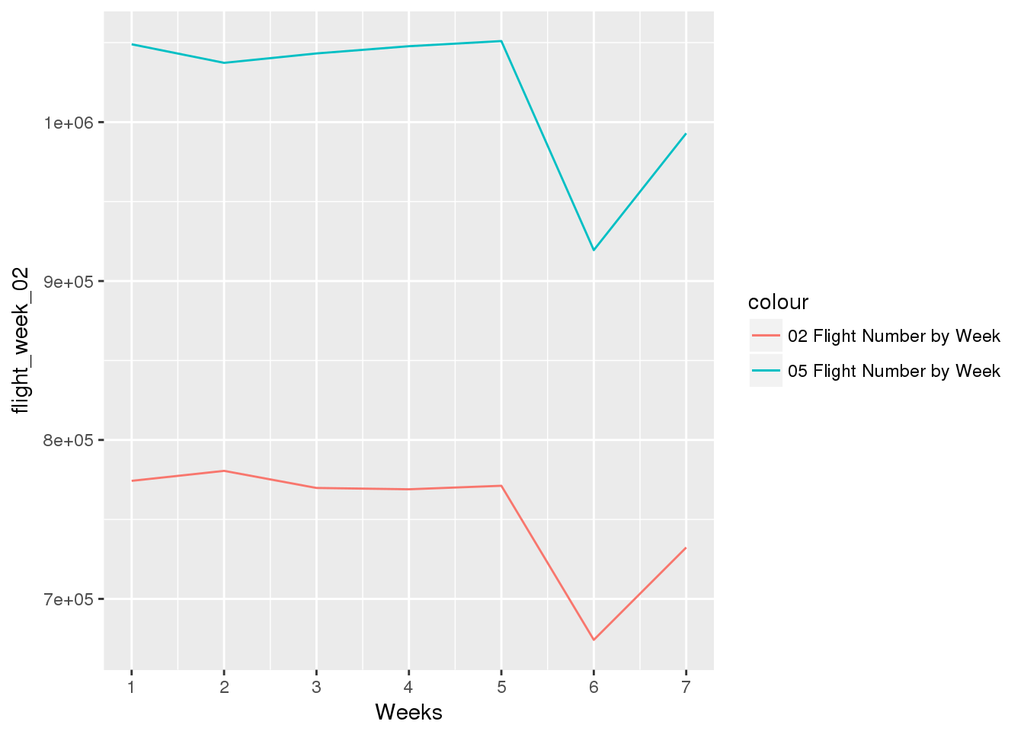

### Cancellation By Day of Week

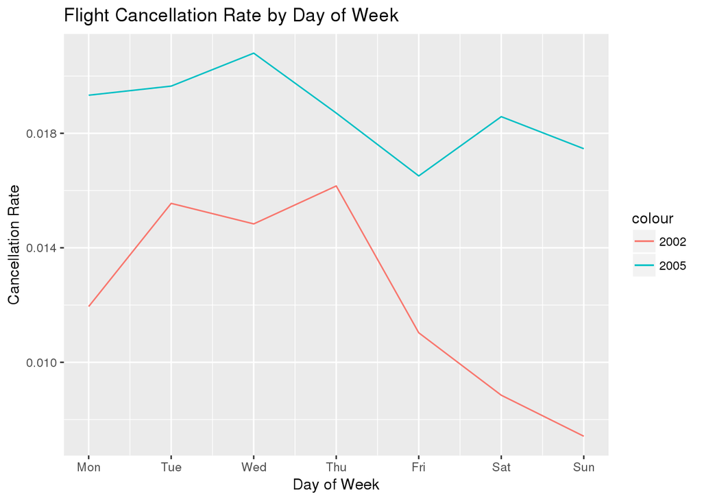

One of the smaller working or life cycle for people is the week, like going to work place on Mondays and going back home or go on vacations on the beginning of the weekends. This section illustrated reasonable analysis and talked about possible causes over each day of week.

### Arrival delay by day of week

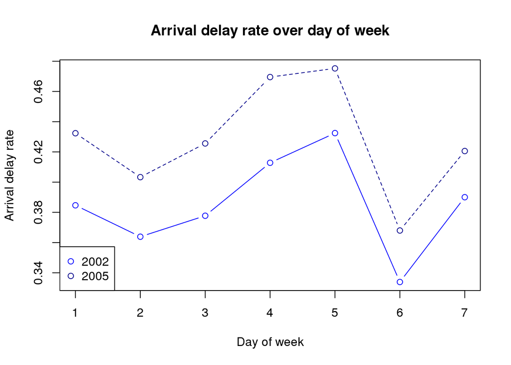

Arrival delay rate: It is clear in the figure that both year have exact same trends over the day of week for average arrival delay rate, with higher value for Thursdays and Fridays and lowest value for Saturdays. During Fridays, people maybe flying back home or from home for short trips, while for Saturdays, people may tend to be stay where they are for the middle of weekends. However, year of 2005 obviously has higher values in comparison with year of 2002. Reasons may because of larger number of flights were scheduled for 2005 instead of 2002, may resulting in higher probability of air traffic.

### Flight number by origin airport

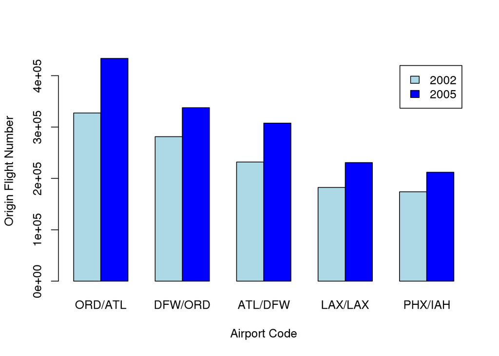

### Cancellation by origin airport

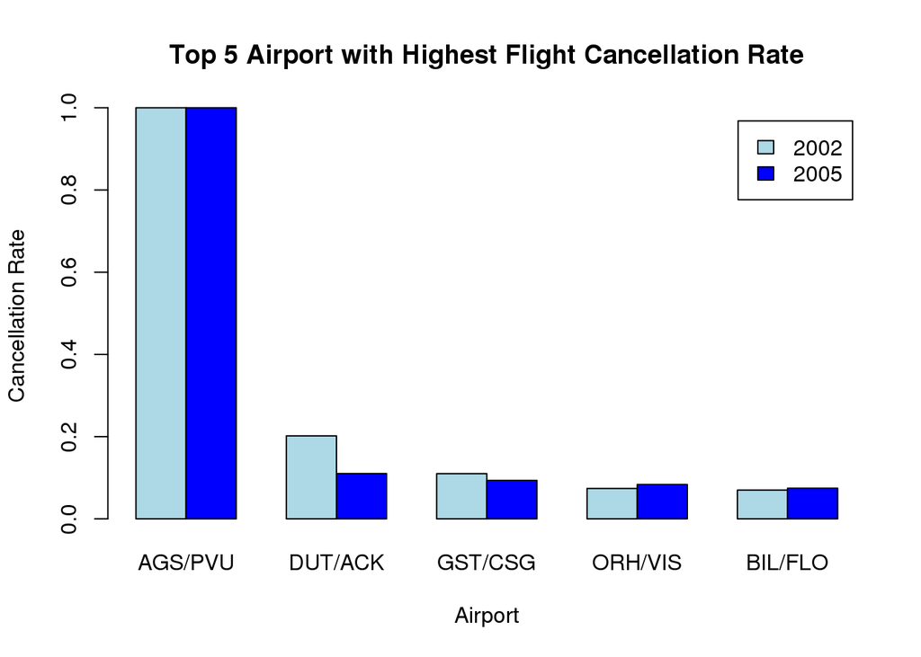

IATA Airport Codes have be provided along the dataset, which is a number around 291. With this large number of airports, it is not reasonable to tell what happened to each of them. The group has decided to have top 5 airports analyzed to show their corresponding cancellation rate, number of flights, and arrival delay rate.

All flights were cancelled originated from Augusta Regional Airport (AGS), which is a city-owned public airport seven miles south of Augusta, in Richmond County, Georgia in 2002. All flights were cancelled originated from Provo Municipal Airport (PVU), which is a public airport two miles west of Provo, in Utah County, Utah in 2005. In 2002, approximately 20% of flights at Unalaska Airport (DUT) were cancelled, and this airport was ranked second highest cancellation rate. The extremely high cancellation rate might be affected by the airport size, location, and capacity. The AGS only have one terminal (in 2002 & 2005) and only serve a small town, as well as PVU.

The scheduled flights of 2005 for each airport are obviously higher than the 2002“s. Among them, ORD (O’Hare International Airport) is the busiest airport in 2002, while the busiest airport is ATL (Hartsfield-Jackson Atlanta International Airport) in 2005. However, compared with the same airport from the different year, ORD only has the small increment regarding the scheduled flights from 2002 to 2005, while the ATL has the huge increment (approximately 80%), which potentially represent a rapid economy development in Atlanta area.

### Arrival delay by airports

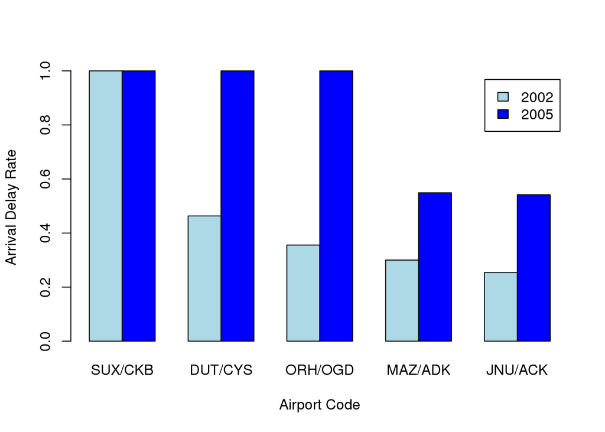

Sioux Gateway Airport(SUX) has all its schedule flights delayed during the year of 2002, which is a public and military use airport in Woodbury County, Iowa state. This high arrival delayed rate may caused by military missions, which is understandable. North Central West Virginia Airport(CKB), and Cheyenne Regional Airport(CYS), are joint-use airport both for public and military and have 100% arrival delay rate for year of 2005, which could caused by the same reason as SUX. Ogden-Hinckley Airport(OGD), have all of their scheduled flights delayed as well for year of 2005, which has been billed as Utah’s busiest municipal airport for private planes. Since private jets absolutely have higher priority of landing, it makes sense to have high arrival delay rate.

### Flight number by origin state

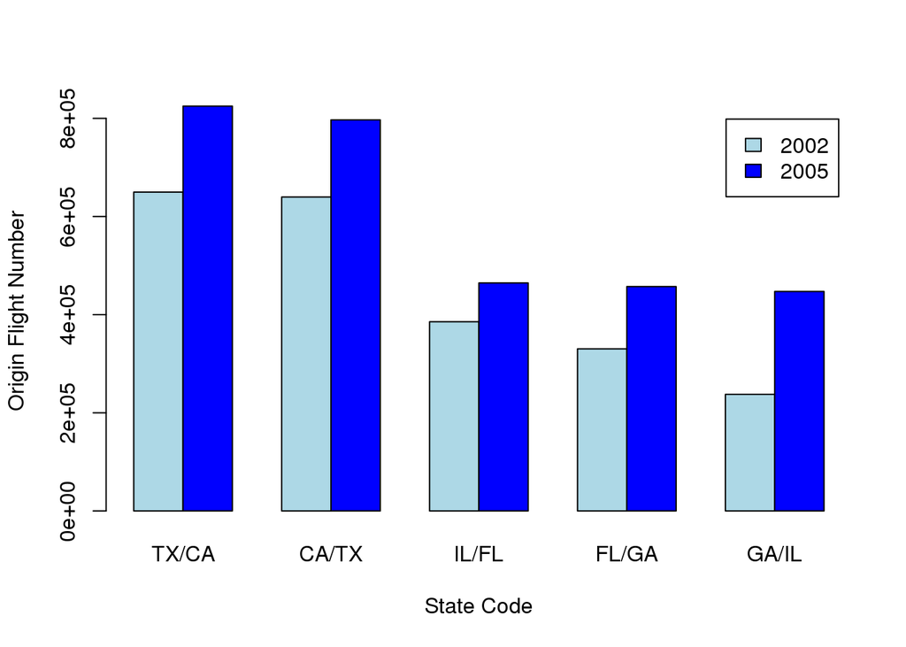

### Cancellation by origin state

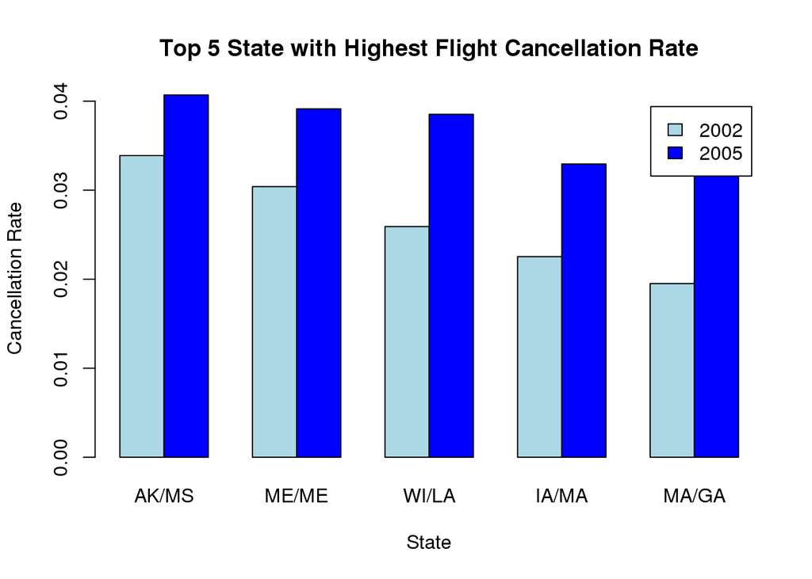

The cancellation rates for the top 5 state are all higher in 2005 than in 2002, which is consistent to the results we found when doing analysis for day of week and month for each year. In 2002, Alaska (AK) showed the highest cancellation rate, while Maine (ME), Wisconsin (WI), Iowa (IA), Massachusetts (MA) ranked in sequence. In 2005, Mississippi (MS) showed the highest cancellation rate, while Maine (ME), Louisiana (LA), Massachusetts (MA), Georgia (GA) ranked in sequence. We could notice that both Maine (ME) and Massachusetts (MA) gave high cancellation rate in the two years, and these two states are next to each other in very north part of America. The reason could be the geometrical, since they could have snow storm in winter which may have huge impact on flights.

Connecting cancellation rate with flight number, GA shows up in the top five highest flight cancellation rate state in 2005 along with its flight number has approximately 100% increments from 2002 to 2005. Both TX and CA has a explicit rising, but CA finally took over the first place in 2005. IL does not increase a lot, and drop its place from third to fifth, which might caused by the largest airport, ORD“s growth is slowing down.

### Arrival delays by origin state

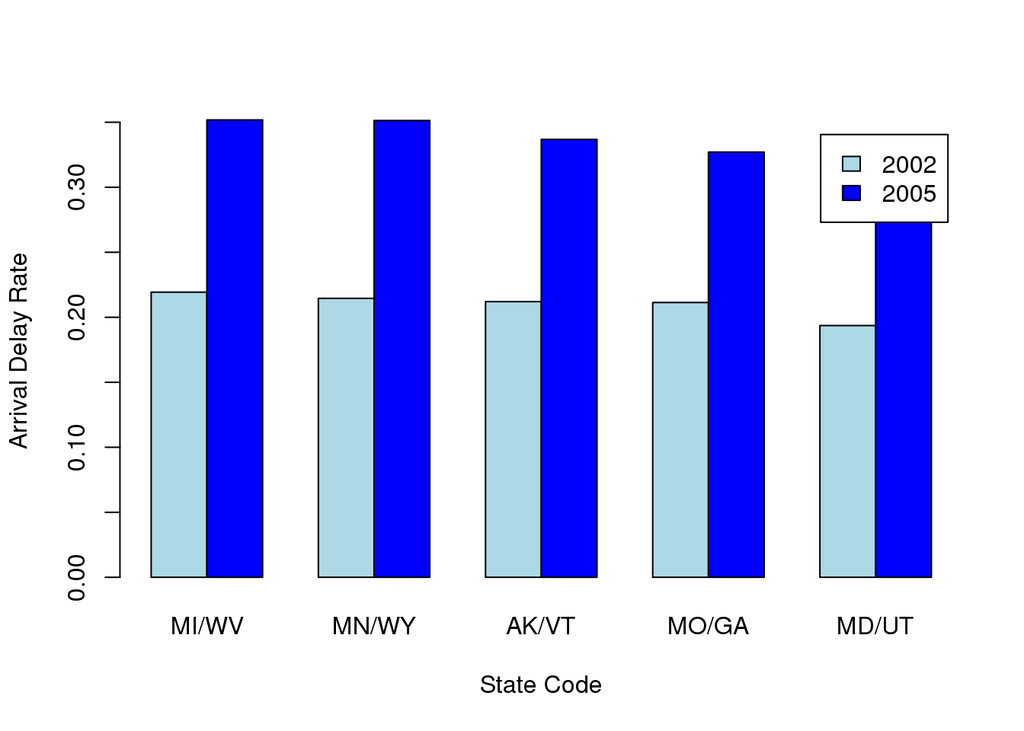

### Flight number by carrier

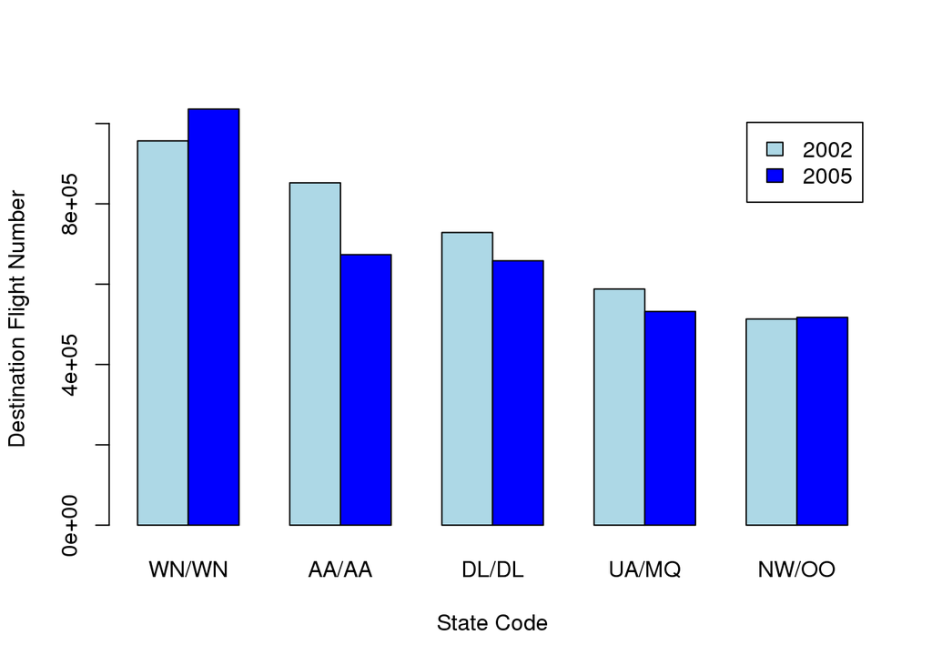

### Cancellation by carrier

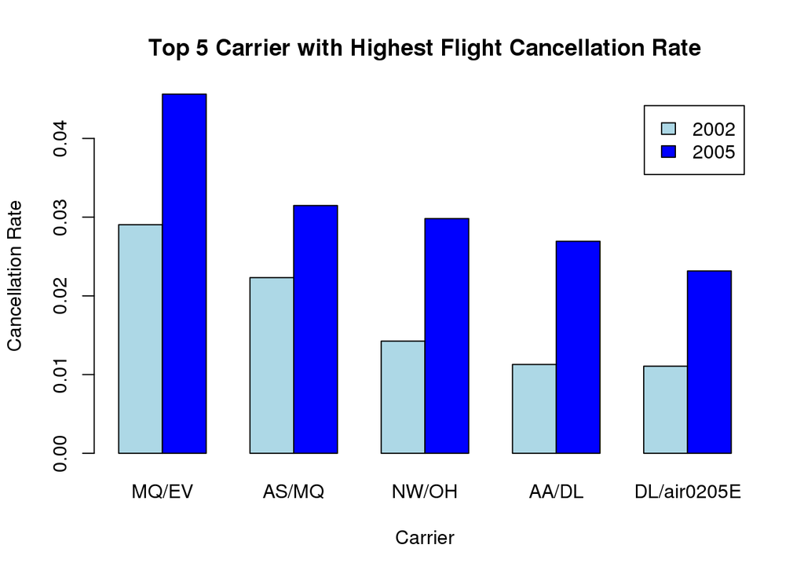

### Arrival delay by carrier

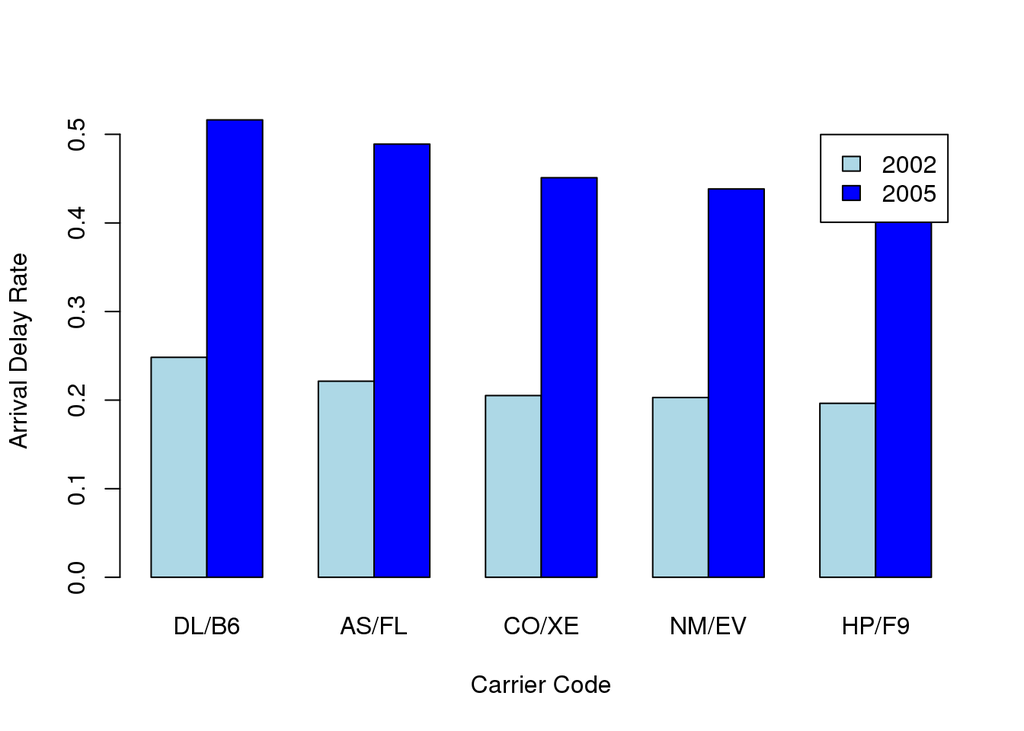

Delta ranked first in year of 2002, with noticeable difference between second carrier. One the other hand, JetBlue ranked first during year of 2005. Still, carriers with top 5 arrival delay rate are totally different for each year.

## By cancellation code

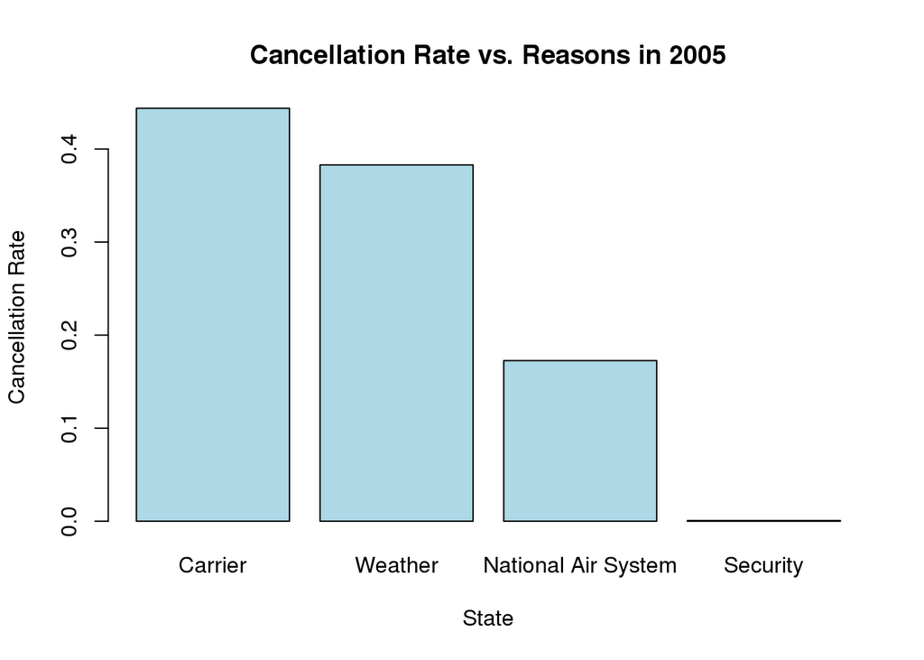

Since all cancellation codes (indicating cancellation reason) in 2002 raw flight data are unavailable, analysis for cancellation reason based on 2005 flight data was the only choice for the group. Cancelled flights were filtered out to see the percentage of cancellation due to each reason (NA records were omitted).

As shown in the figure, we could see that the two main reasons for flight cancellation in 2005 were carrier and weather, while the percentage of carrier was slightly higher than weather. Approximately 20% of cancellation were due to national air system, and very few were due to security.

## Logistic regression

### 2002 Logistic

```r
lg_02<- bigglm.big.matrix( cancelled ~ dayofweek + month + origin + originstate + uniquecarrier, data = air02, family = binomial())
summary(lg_02)$rsq
```

```
## [1] 0.8670049
```

### 2005 Logistic

```r
lg_05<- bigglm.big.matrix( cancelled ~ dayofweek + month + origin + originstate, data = air05, family = binomial())
summary(lg_05)$rsq
```

```
## [1] 0.8152749
```

After fitting logistic regression for 2002 and 2005 separately, the results demonstrated that the r-square for 2002 is 0.867, and the r-square for 2005 is 0.815, which means that the variables we selected could explain more than 80% of the variance for these two years. The r-square in 2002 is higher than in 2005, which means other factors not included in the model might have some influence on flight cancellation in 2005 rather in 2002.

## Corrlation Between Arrival delays and other delays

Several reasons for airline delays were recorded in the data, including carrier delay, national air system delay, weather delay, security delay, and late aircraft delay. Carrier delay is cause due to circumstances within the airline“s control (e.g. maintenance or crew problems, aircraft cleaning, baggage loading, fueling, etc.). Nasdelay are the delays within the control of the National Airspace System (NAS), including non-extreme weather conditions, airport operations, heavy traffic volume, air traffic control, etc. Security delay is caused by evacuation of a terminal or concourse, re-boarding of aircraft because of security breach, inoperative screening equipment and/or long lines in excess of 29 minutes at screening areas. Late aircraft delay is caused when a previous flight with same aircraft arrived late, causing the present flight to depart late.

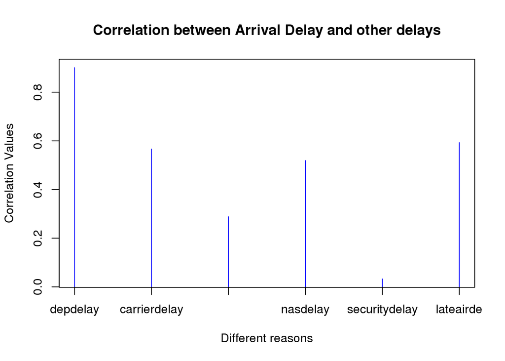

A correlation among the reasons listed and arrival delay has been calculated.It is obviously noticeable that departure delay is the variable recording whether the flight departs late or on time. According to the figure, it is easily to tell that departure delays have strong positive correlations, then carrier delays and late aircraft delays have higher correlation with arrival delay. Reasons for these kind of delays with higher correlation would be addressed in the following sections.

## Different delay rate

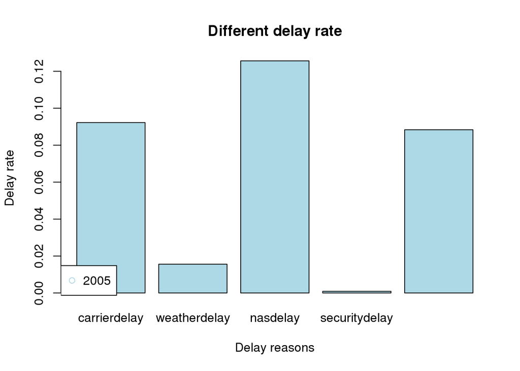

The group has also investigated the percentage of different kind of delays for the year of 2005, since there“s no records for year of 2002. Only nasdelays happened more than 10% of the time within the year of 2005, then carrier delays and late aircraft delays occurred 9% of the time, which also indicated the carrier delays and late aircraft delays are worthy looking at, since nasdelays has no related variables provided in the data given.

## Arrival delay time range caused by different reasons

The group looked into the value provided in all delay related columns, and found that values are actually offered in minutes, which drew the attention to break the delay time into bins. Delays within an hour are usually tolerable for most people. If the delay time is be more than 1 hour, less than 4 hours, which is like a half work day, or say that passengers have to have meals within the airport, then it is another level of tolerance. When the delay time extended to over 4 hours, less than 12 hours, then it is a length of a work day. Over 12 hours means at least a rest at the airport, which is annoying and really tired. These are the reasons the group has divided the delay time into these bins. The rate in the graph was calculated as the number of delays for that certain reason over the total number of arrival delays for that time range.

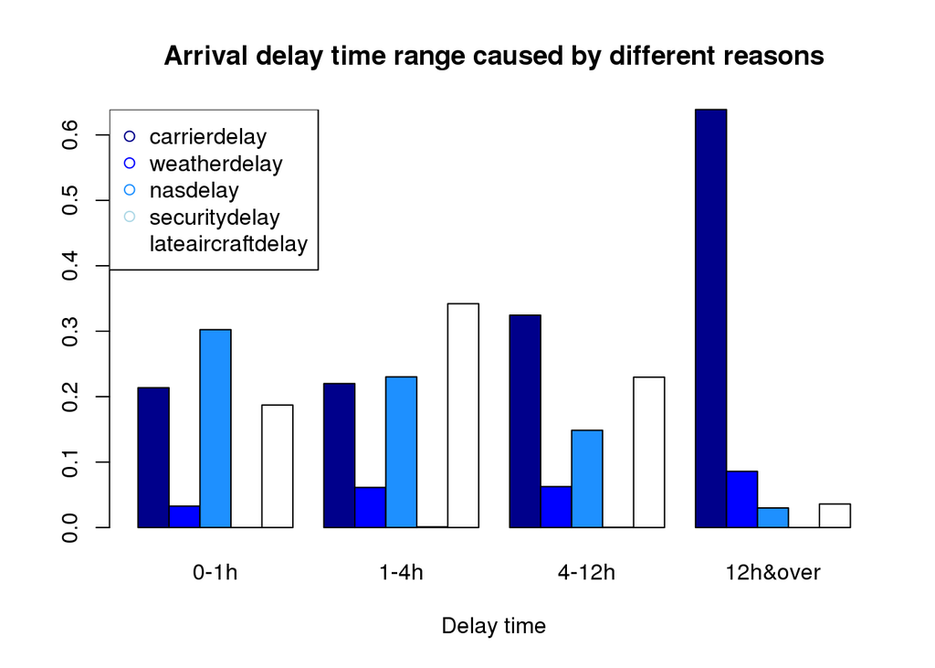

The graph plotted the rate for each time range as y axis, and x axis as different time ranges. For the first 3 time bins, carrier delay, nasdelay and late aircraft delay donated between 70% to 80% of the delays. For delays over 12 hours, carrier delay contributed more than 60% of the delays, and weather delay here donated 1 around 10% of the delays. Weather might be a major reason for delays as people may think, but here, according to data and graph, only if the delay time is over 12 hours, then weather comes into the game.

The group has looked into the distribution for each single delay reason. Carrier delay has increasing trend as the time range increases. National Air System delays has been decreasing as the time range increases, which reflected the fact of air traffic operations that only keep aircrafts in waitlist for some time, and it would not be a long time. As late aircraft delay may be affected by both nasdelays and carrier delays, it is a close-to-normal distribution, just as shown in the graph.

## Carrier vs Late Aircraft Delay

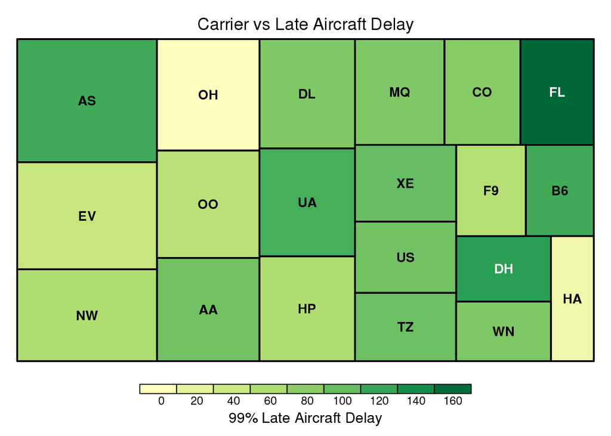

Although this type of delay can be caused by various factors ranging from weather to heavy air traffic, we should expect the delays to vary by carrier. From the above treemap 1, we can see that AirTran Airways Corporation (FL) experiences one of the worst carrier delays, having the highest 99th percentile carrier delay of 163 minutes. This airline is followed by Independence Air (DH) (124 minutes), Alaska Airlines (AS) (117 minutes), JetBlue Airways (B6) (115 minutes) and United Airlines (UA) (111 minutes). Note that AirTran Airways, Independence Air and JetBlue Airways had one of the less worse Carrier Delays. On the other hand, Comair (OH) experiences no carrier delay even in the worst 1% of times, having the lowest 99th percentile carrier delay of 0 minutes. This airline is followed by Hawaiian Airlines (HA) (15 minutes), Atlantic Southeast Airlines (EV) (47 minutes), Skywest Airlines (OO) (54 minutes), Frontier Airlines (F9) (58 minutes), Northwest Airlines (NW) (60 minutes) and America West Airlines (HP) (60 minutes). Note that Comair, Atlantic Southeast Airlines, Skywest Airlines, Northwest Airlines and America West Airlines had one of the worst Carrier Delays. If you are booking a flight (which you know has a connecting flight before) and want to hedge against experiencing very long late aircraft delays, Comair is probably your best bet and AirTran Airways is probably your worst bet.

## Carrier vs Late Aircraft Delay

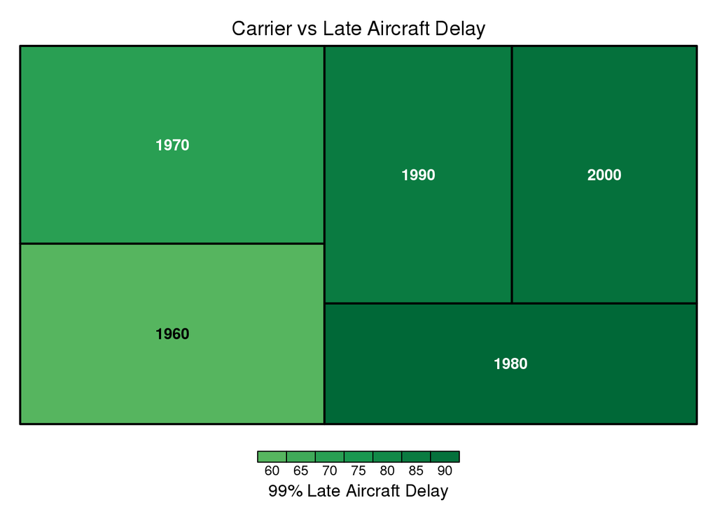

## Delay by Engine Type

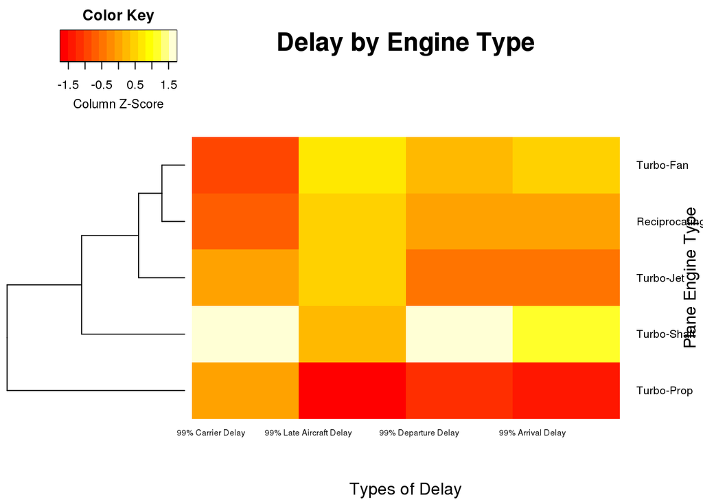

From the heatmap 1 above, we see that carrier delay does not vary a lot by engine type. But “turbo-shaft” engines have significantly higher delays than the other engines with a 99th percentile carrier delay of 87 minutes. Turbo-shaft engines are mostly used in helicopters. Since they have gear systems that can be complex and might break down, aircrafts with turbo-shaft engines might require more maintenance and hence, have a higher carrier delay. The heatmap 2 showing 99.99th percentile of late aircraft delay shows that “turbo-prop” engines have significantly lower carrier delays than the other engines, with a 99th percentile carrier delay of 433 minutes. This result might be indicative of the fact that turbo-prop engines are fuel efficient and regarded as the most efficient engine at mid-range speed.

From the heatmap 1 above, we see that “turbo-prop” engines have significantly lower late aircraft delays than the other engines with a 99th percentile carrier delay of 50 minutes. Turbo-prop engines are known to be very fuel efficient and most efficient at mid-range speed. Aircrafts that use turbo-prop engines might have a lower late aircraft delay because of this reason. The heatmap 2 showing 99.99th percentile of late aircraft delay also implies that “turbo-prop” engines have significantly lower late aircraft delays than the other engines with a 99th percentile late aircraft delay of 230 minutes.

## Delay by Engine Type

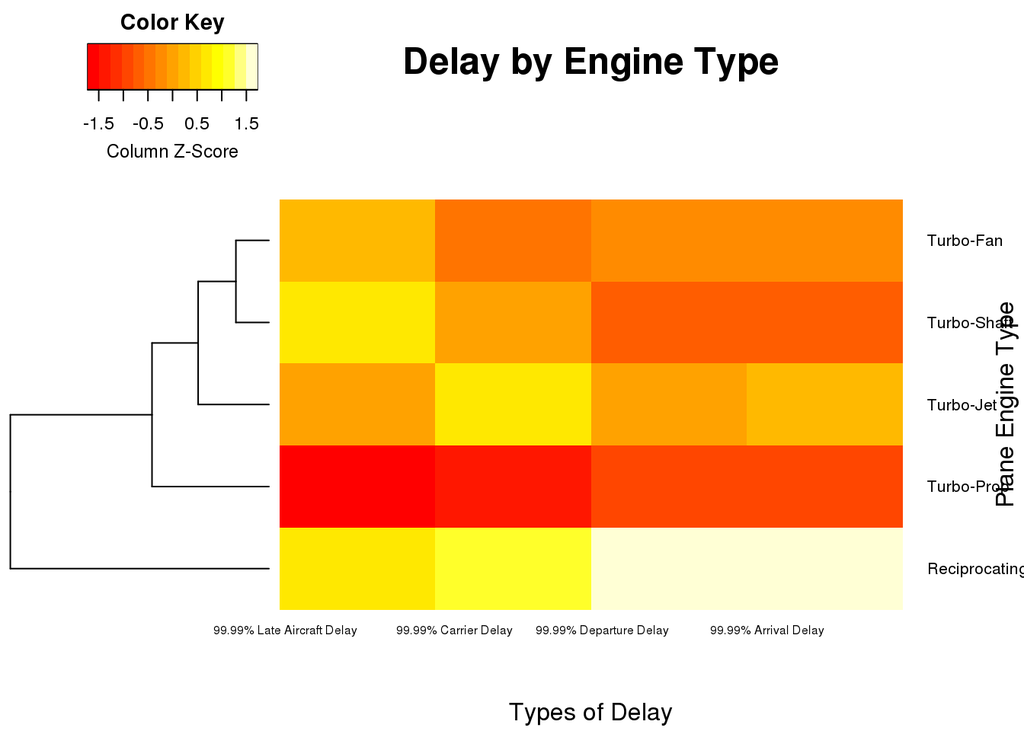

The heatmap displaying 99.99th percentile delays, highlights the contrast between “reciprocating” (piston) engines and “turbo-prop” engines. Piston engines have the highest 99.99th percentile arrival and departure delay, whereas turbo-prop engines have the lowest 99.99th percentile arrival and departure delay. This is an indication of the superiority of turbo-prop engines over piston engines, a fact which is well established in the airline industry. Turbo-prop engines have far fewer moving parts and offer greater reliability than piston engines. You can generally log more hours on turbo-prop before bringing it in for inspection. The power of a turbine engine almost always allows turboprop aircraft to travel at higher speeds than piston aircraft, minimizing the delay.

## Stream Graph

[interactive chart not shown]

# Appendix

GROUP MEMBER CONTRIBUTIONS

Donghan A. Number of flights analysis for 2002 and 2005: 1. By month 2. By day of week 3. By origin airport (top 5) 4. By origin state (top 5) 5. By carrier (top 5) B. Mering each individual works to final group project.

Lijun A. Cancellation Rate analysis for 2002 and 2005: 1. By month 2. By day of week 3. By origin airport (top 5) 4. By origin state (top 5) 5. By carrier (top 5) 6. By cancellation reason B. Logistic model for cancellation prediction

Dilin Delay related analysis Correlation among delays Arrival delay rate for each year: 1. Monthly 2. Day of week 3. Origin airport (top5) 4. Origin state (top5) 5. Carrier (top 5) Frequency in bins(time ranges) for different delay reasons.

Saumil Following analysis was done: 1. Carrier, Late Aircraft Delay Analysis (using 99th and 99.99th percentile values) A. By Carrier (Treemap) B. By Plane Year (Treemap) C. By Engine Types (Heatmap) D. By Carrier and Plane Year (Carrier Delay only) (Stream graph) 2. Arrival, Departure Delay Analysis (using 99th and 99.99th percentile values) A. By Engine Types (Heatmap) 3. Cancellation/Diversion Rate Analysis A. By Plane Year (Treemap)

I also performed data pre-processing and combining tasks, which are described in detail under the “Data Processing” section above.

# REFERENCES

https://www.bts.gov/explore-topics-and-geography/topics/airline-time-performance-and-causes-flight-delays

http://www.shorelineaviation.net/news---events/bid/50442/Piston-Engine-Aircraft-vs-Turboprop-Engine-Aircraft

http://www.boldmethod.com/learn-to-fly/systems/the-4-types-of-turbine-engines/

http://www.traveller.com.au/major-airlines-with-the-oldest-fleet-are-older-planes-less-reliable-to-fly-gxnsmn

http://aspmhelp.faa.gov/index.php/Types_of_Delay#NAS_Delay